# Reproducible Research Assignment: Course Project 1

Sally Pattison

Monday, May 09, 2016

## Loading and preprocessing the data

1. & 2. Code used to load the data (no preprocessing necessary) -

```r
temp <- tempfile()
download.file("https://d396qusza40orc.cloudfront.net/repdata%2Fdata%2Factivity.zip",temp)
activity <- read.csv(unz(temp, "activity.csv"), na.strings = "NA")
unlink(temp)
```

## What is the mean total number of steps taken per day?

1. Code to calculate the total number of steps taken each day -

```r
tot_daily_steps <- with(activity, aggregate(steps, by = list(date), sum))
colnames(tot_daily_steps) <- c("date", "total_steps")
```

2. Code to plot a histogram of the total number of steps taken each day -

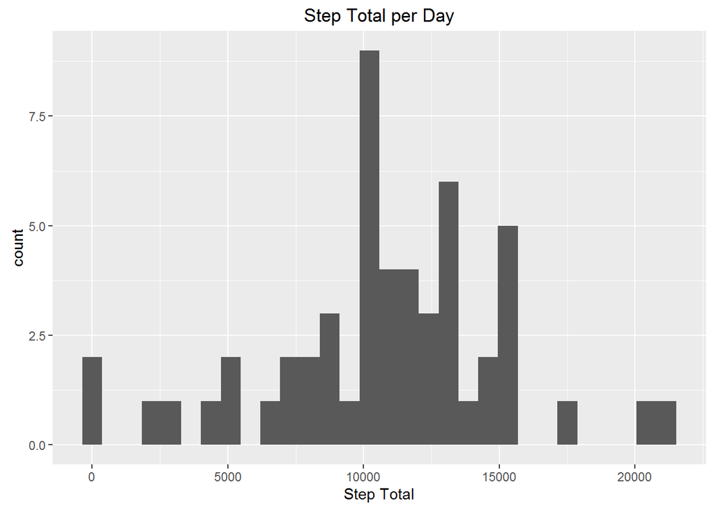

```r
library(ggplot2)
hist1 <- ggplot(tot_daily_steps, aes(total_steps))
hist1 + geom_histogram() + labs(title = "Step Total per Day", x = "Step Total")
```

3. Code to calculate the mean & median of the total number of steps taken each day -

```r
summary <- summary(tot_daily_steps$total_steps)
paste("Mean total daily steps =", summary[4], "& median total daily steps =", summary[3])
```

```
## [1] "Mean total daily steps = 10770 & median total daily steps = 10760"
```

## What is the average daily activity pattern?

1. Code to plot a time series of 5-min interval vs average steps taken per interval (averaged over all days) -

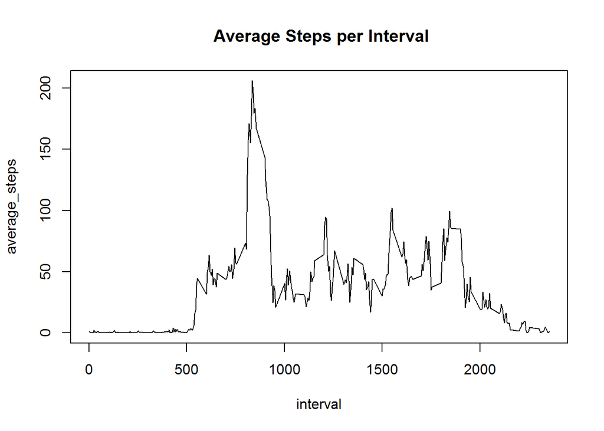

```r
av_int_steps <- with(activity, aggregate(steps, by = list(interval), mean, na.rm = TRUE))
colnames(av_int_steps) <- c("interval", "average_steps")
with(av_int_steps, plot(interval, average_steps, type = "l", main = " Average Steps per Interval"))
```

2. Code to determine which interval contains the maximum average number of steps -

```r
max_av_int_steps <- which.max(av_int_steps$average_steps)
print(paste("The interval which on average contains the maximum number of steps is", av_int_steps$interval[max_av_int_steps]))
```

```
## [1] "The interval which on average contains the maximum number of steps is 835"
```

## Imputing missing values

1. Code to calculate the number of rows where there are missing values (NAs) -

```r
missing <- sum(is.na(activity))
print(paste(missing, "rows contain missing data"))
```

```
## [1] "2304 rows contain missing data"
```

2. Strategy for imputing missing data: It was considered that when imputing missing values for the number of steps per interval it would be most appropriate to use the mean for the missing interval rather than the daily mean as there is likely to be a greater difference in movement throughout a 24h period rather than between days.
3. Code to create a dataset called activity2 where the missing values for the number of steps per interval are filled in with the mean calculated for that 5 min interval -

```r
## calculate df correlating interval with averages ##

av_int_steps <- with(activity, aggregate(steps, by = list(interval), mean, na.rm = TRUE))
colnames(av_int_steps) <- c("interval", "average_steps")

## add column to activity dataset for measured + imputed data ##

activity$steps_noNA <- activity$steps

## merge activity and av_int_steps datasets by interval to create column of interval averages in the activity dataset ##

activity <- merge(av_int_steps, activity, by.y = "interval", all = TRUE)

## ID which rows in activity dataset contain NAs for the number of steps taken ##

NA_index <- is.na(activity$steps_noNA)

## for each of these rows replace NAs in steps_noNA column with average_steps from same row  ##

activity$steps_noNA[NA_index] <- activity$average_steps[NA_index]

##create new dataframe containing only columns of original dataframe ##

activity2 <- activity[,c("interval", "steps_noNA", "date")]
colnames(activity2) <- c("interval", "steps", "date")
```

4. Code to plot a histogram of the total number of steps taken each day using the activity2 dataset (missing values are imputed) and code to report the mean and median number of steps per interval for the same dataset -

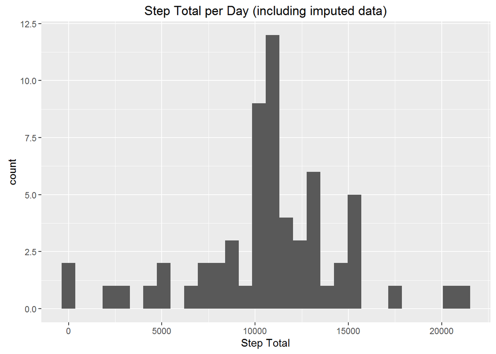

```r
## calculate total daily steps from activity2 dataset ##

tot_daily_steps2 <- with(activity2, aggregate(steps, by = list(date), sum))
colnames(tot_daily_steps2) <- c("date", "total_steps")

## plot histogram of total daily steps from activity2 dataset ##
library(ggplot2)
hist1 <- ggplot(tot_daily_steps2, aes(total_steps))
hist1 + geom_histogram() + labs(title = "Step Total per Day (including imputed data)", x = "Step Total")
```

```r
## calculate the mean & median of the total daily steps from activity 2 dataset and reprint the equivalents for the activity dataset for easy comparison ##

summary2 <- summary(tot_daily_steps2$total_steps)
paste("Mean total daily steps (including imputed data) =", summary2[4], "& median total daily steps (including imputed data) =", summary2[3])
```

```
## [1] "Mean total daily steps (including imputed data) = 10770 & median total daily steps (including imputed data) = 10770"
```

```r
paste("Mean total daily steps (including missing data) =", summary[4], "& median total daily steps (including missing data) =", summary[3])
```

```
## [1] "Mean total daily steps (including missing data) = 10770 & median total daily steps (including missing data) = 10760"
```

Imputing values for missing data has increased the median value for total daily steps from 10760 to 10770, but the mean remains the same at 10770. As the difference is small the impact of imputing missing data is likely to be small.

## Are there differences in activity patterns between weekdays and weekends?

The dataset used to answer this question has replaced missing values for the number of steps taken per interval with the mean number of steps per interval. N.B. If the mean daily average had been substituted instead of the mean interval average, differences between weekdays and weekends would probably be more exaggerated.

1. Code to create a factor variable indicating if the date listed is a weekday or weekend -

```r
activity2$day <- weekdays(as.POSIXlt(activity2$date))
activity2$day_type <- "weekday"
saturday <- activity2$day == "Saturday"
sunday <- activity2$day == "Sunday"
for(i in saturday){
        activity2$day_type[saturday] <- "weekend"
}
for(i in sunday){
        activity2$day_type[sunday] <- "weekend"
}
activity2$day_type <- as.factor(activity2$day_type)
```

2. Code to produce a panel plot of the average number of steps taken per interval averaged across all week days or all weekend days using activity 2 dataset which includes imputed values in place of missing values.

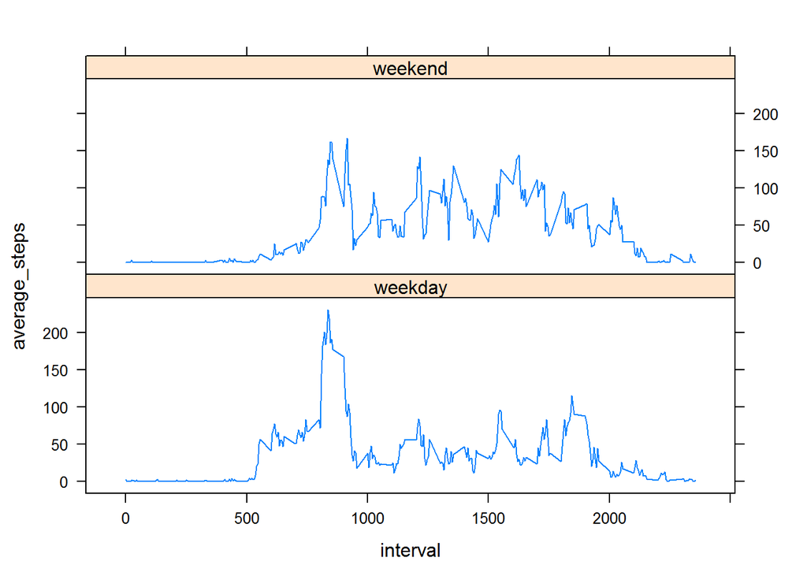

```r
## calculate df correlating interval with average number of steps separated by weekday vs weekend ##

df <- with(activity2, aggregate(steps, by = list(day_type, interval), mean, na.rm = TRUE))
colnames(df) <- c("day_type", "interval", "average_steps")

##create plot ##

library(lattice)
xyplot(average_steps ~ interval | day_type, df, layout = c(1,2), type = "l")
```

Superficial comparison of the 2 plots suggests that on average the number steps taken throughout the day are fewer on weekdays during what is most likely to be working hours. Also, on averge more steps are taken starting earlier in the morning, which again most likely correlates with people getting up earlier and going to work.